# Phenological traits

## Plots for repro. timing

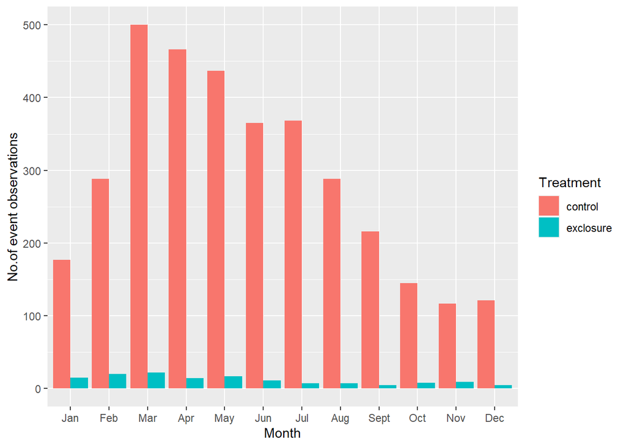

```r
maletraits=read.csv("male_S_month.csv")

DMmaletraits=maletraits%>%
  filter(Species=="DM")

DMmaletraits%>%
  ggplot(data=DMmaletraits, mapping=aes(x=reorder(Month, Month_num), y=Count, fill=Treatment))+
  geom_col(position=position_dodge())+
  xlab("Month")+ylab("No.of event observations")
```

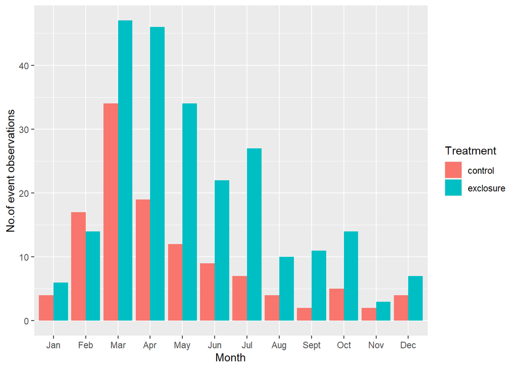

```r
PBmaletraits=maletraits%>%
  filter(Species=="PB")

PBmaletraits%>%
  ggplot(data=PBmaletraits, mapping=aes(x=reorder(Month, Month_num), y=Count, fill=Treatment))+
  geom_col(position=position_dodge())+
  xlab("Month")+ylab("No.of event observations")
```

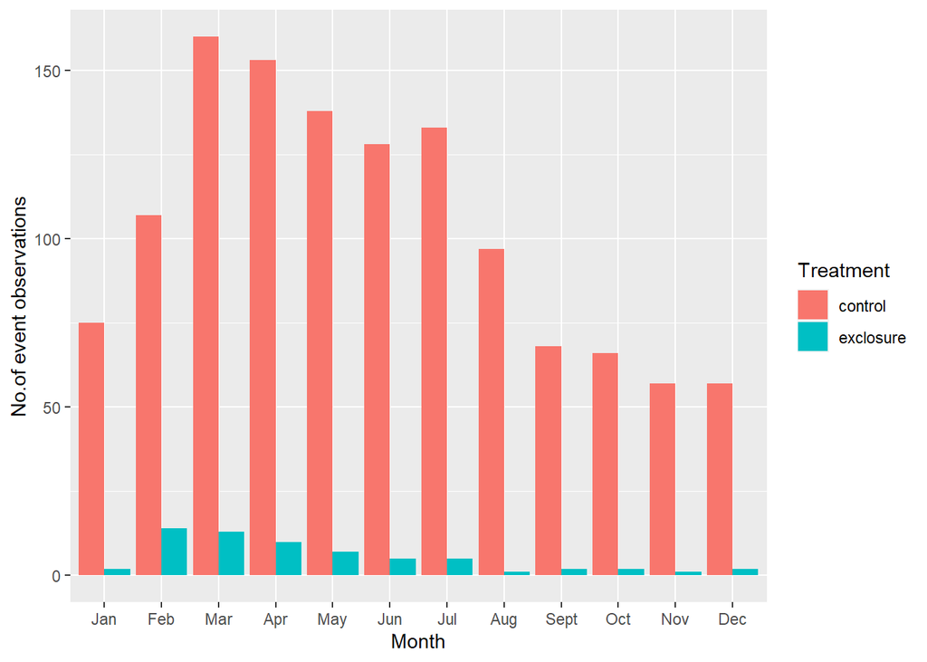

```r
DOmaletraits=maletraits%>%
  filter(Species=="DO")

DOmaletraits%>%
  ggplot(data=DOmaletraits, mapping=aes(x=reorder(Month, Month_num), y=Count, fill=Treatment))+
  geom_col(position=position_dodge())+
  xlab("Month")+ylab("No.of event observations")
```

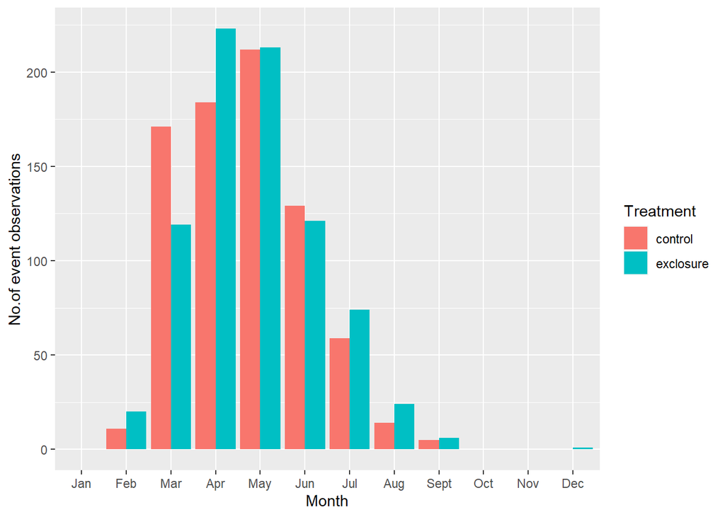

```r
PPmaletraits=maletraits%>%
  filter(Species=="PP")

PPmaletraits%>%
  ggplot(data=PPmaletraits, mapping=aes(x=reorder(Month, Month_num), y=Count, fill=Treatment))+
  geom_col(position=position_dodge())+
  xlab("Month")+ylab("No.of event observations")
```

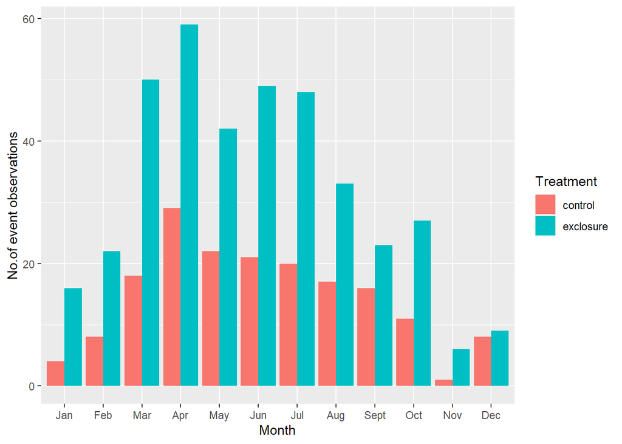

```r
PFmaletraits=maletraits%>%
  filter(Species=="PF")

PFmaletraits%>%
  ggplot(data=PFmaletraits, mapping=aes(x=reorder(Month, Month_num), y=Count, fill=Treatment))+
  geom_col(position=position_dodge())+
  xlab("Month")+ylab("No.of event observations")
```

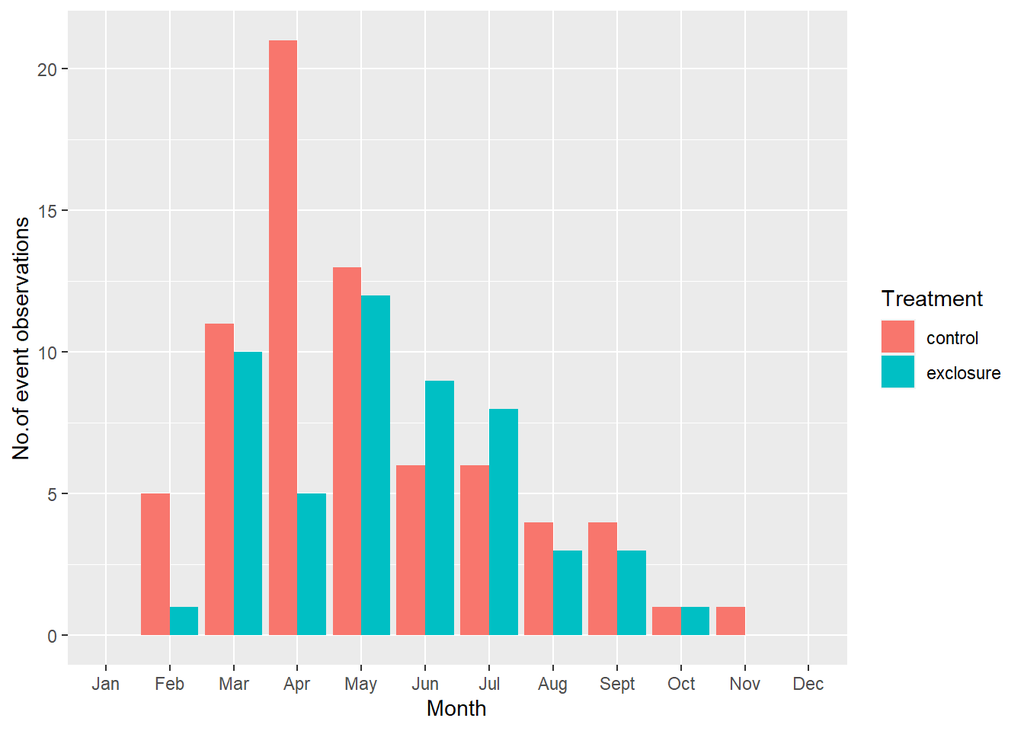

```r
PEmaletraits=maletraits%>%
  filter(Species=="PE")

PEmaletraits%>%
  ggplot(data=PEmaletraits, mapping=aes(x=reorder(Month, Month_num), y=Count, fill=Treatment))+
  geom_col(position=position_dodge())+
  xlab("Month")+ylab("No.of event observations")
```

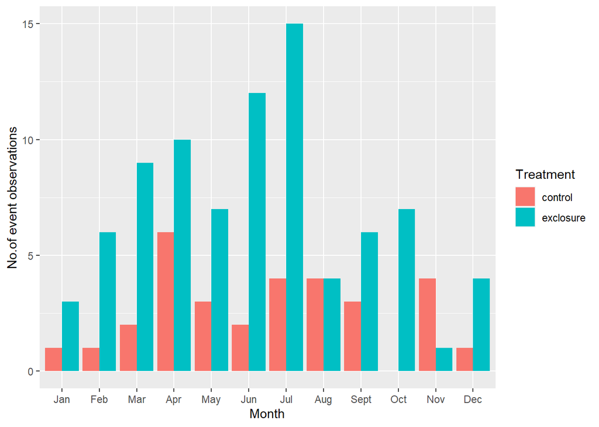

```r
PMmaletraits=maletraits%>%
  filter(Species=="PM")

PMmaletraits%>%
  ggplot(data=PMmaletraits, mapping=aes(x=reorder(Month, Month_num), y=Count, fill=Treatment))+
  geom_col(position=position_dodge())+
  xlab("Month")+ylab("No.of event observations")
```

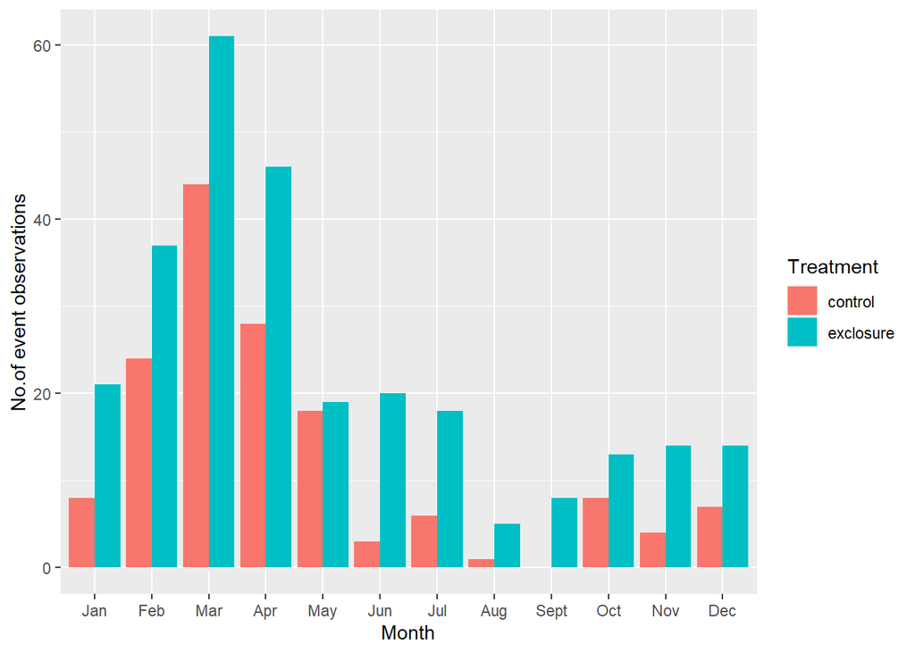

```r
RMmaletraits=maletraits%>%
  filter(Species=="RM")

RMmaletraits%>%
  ggplot(data=RMmaletraits, mapping=aes(x=reorder(Month, Month_num), y=Count, fill=Treatment))+
  geom_col(position=position_dodge())+
  xlab("Month")+ylab("No.of event observations")
```

## *TO FIGURE OUT/ TO DISCUSS WITH MORGAN:*

- why I’m not getting median estimates for the onset for some species (sample size?) (maybe my input data is weird??)
- how to get estimates that does not include year (but Julian date…)
- should I include DS (but too few samples in exclosure <10)
- Why are there K-rat species in exclosures? how should I account for that?
- if i want to see if the onset of events is moving earlier/later, should I just focus on identifying the first observation date per month per year?
- should I choose the months with greatest proportion of reproductive trait observations, choose when the earliest is for that period and then collect dates annually?
- will it be interesting to know the proportion of individuals that exhibit reproductive characteristics annually, and see if there is a pattern in control and exclosure set-ups, and/or see if there are fewer/more of them being reproductively prepared?